# R Functions and Environments

John Kane

2018-02-02

The content of this post nearly became a Stack Overflow question. In the process of going about making a [reproducible example](https://stackoverflow.com/questions/5963269/how-to-make-a-great-r-reproducible-example) I solved the problem, as often happens. It took a bit of time to stich together several other SO posts before I arrived at it. Hopefully when someone else comes across the issue maybe this will provide some immediate assistance.

The following is the reprex I went about writing to include in the Stack Overflow post. Suspend your judgment of what this code actually accomplishes to focus on the issues of functions and environments.

In the global environment I have the following list, which I call `lookup`. The purpose of this list is to be able to lookup a `value` based solely on a numeric value.

```r
library(dplyr)
lookup <- list(code = c(1,2,3),
                value = c('df1','df2','df3'))
```

To illustrate what’s going I’ll use two “function familes,” for lack of a better word, `f` and `g`. Throughout this post I’ll refer to different variants of the `f` and `g` functions by using `f1`,`g1`,`f2`,`g2`, etc.

- The `f` functions conditionally create dataframes. They takes as its lone argument a vector of integers.
- The `g` functions process each dataframe created in `f` in a similar way, by unlisting and printing it. The `g` functions are called from the `f` functions through an `lapply` call.

```r
f1 <- function(x){

  if(1 %in% x){
    df1 <- data.frame(a = 1:2, b=3:4)
  }

  if(2 %in% x){
    df2 <- data.frame(a = 11:15, b= 16:20)
  }

  if(3 %in% x){
    df3 <- data.frame(a = 100, b = 200)
  }

  lapply(x,g1) %>% rm() # lapply returns a list, in this case it would be a NULL list so pass that to rm().
}

g1 <- function(y){

  object_name <- lookup[["value"]][[y]]

  get(object_name) %>%
    unlist() %>%
    print()
}
```

### Initial testing

Since we’re calling `g` from within `f` we want to make sure that `g` works outside of `f`. That way if `f` fails then we wouldn’t think that it was because of `g`.

When we create `df1` in the global environment and want to unlist and print it, we can call `g1(1)` and it works like we’d expect.

```r
df1 <- data.frame(a = 1:2, b=3:4)
g1(1)
```

```
## a1 a2 b1 b2
##  1  2  3  4
```

However when we attempt to conditionally create `df1` and pass it to `g1` (that is call `f1(1)`) it fails:

```r
f1(1)
```

```
## Error in get(object_name): object 'df1' not found
```

### Why didn’t that work?

The best way I can think to describe it is that the function `g` doesn’t have any of the objects `df1`, `df2`, or `df3` in the local environment created on execution. So it goes and looks for them in `.GlobalEnv` where they are shielded by the environment of `f`. So it appears that `g` can’t cross into `f`’s environment to use things created there.

This is my attempt at illustrating the R environment I created:

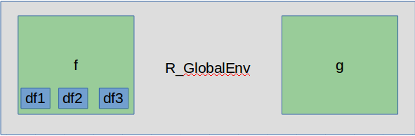

So a solution would be to tell `g` to explicitly look in `f`’s environment. What is the name of the environment created when `f` is executed? Consider the function `f2` which prints the name of the environment that dataframe `df1` is created in.

```r
f2<- function(x){
  df1 <- data.frame(a = 1:2, b=3:4)
  print(environment(df1))
}
f2(1)
```

[output not shown]

### Explicitly create a new, named environment

Consider this function `f3`. This creates an new environment with the call to `new.env()` then assigns any dataframes created by the function to that environment. For the sake of consistency call the `g` function called by `f3` `g3`, I’m skipping `g2`. `g3` takes an additional argument beyond the vector of integers, an environment to look in.

```r
f3 <- function(y){

 e <- new.env()

 if(1 %in% y){
   e$df1 <- data.frame(a = 1:2, b=3:4)
  }

 if(2 %in% y){
  e$df2 <- data.frame(a = 11:15, b= 16:20)
  }

 if(3 %in% y){
  e$df3 <- data.frame(a = 100, b = 200)
 }

 lapply(y,g3,look_in = e) %>% rm()

}

g3 <- function(y,look_in){

  object_name <- lookup[["value"]][[y]]

  get(object_name, envir = look_in) %>%
    unlist() %>%
    print()
}
```

Test on some new data:

```r
t1 <- c(1,3)
t2 <- c(2,3)
f3(t1)
```

```
## a1 a2 b1 b2
##  1  2  3  4
##   a   b
## 100 200
```

```r
f3(t2)
```

```
## a1 a2 a3 a4 a5 b1 b2 b3 b4 b5
## 11 12 13 14 15 16 17 18 19 20
##   a   b
## 100 200
```

Now it works!

Note that the environment created within `f3` does not persist after the function executes:

```r
ls(envir = e)
```

```
## Error in ls(envir = e): object 'e' not found
```

### Alternatively, assign to global environment with `<<-`

An alternate solution would be to assign the dataframes to the global environment directly. We’ll do so with functions `f4` and `g4`.

```r
f4 <- function(y){

  if(1 %in% y){
   df1 <<- data.frame(a = 1:2, b=3:4)
  }

 if(2 %in% y){
  df2 <<- data.frame(a = 11:15, b= 16:20)
  }

 if(3 %in% y){
  df3 <<- data.frame(a = 100, b = 200)
 }

  lapply(y,g4) %>% rm()
}

g4 <- function(y){
  object_name <- lookup[["value"]][[y]]

  get(object_name) %>%
    unlist() %>%
    print()
}
```

```r
f4(t1)
```

```
## a1 a2 b1 b2
##  1  2  3  4
##   a   b
## 100 200
```

```r
f4(t2)
```

```
## a1 a2 a3 a4 a5 b1 b2 b3 b4 b5
## 11 12 13 14 15 16 17 18 19 20
##   a   b
## 100 200
```

This works too!

### Which approach is “better?”

I’m genuinely not sure. I’m inclined to think that creating a new environment within the function `f` is better, that way we’re not needlessly cluttering the global environment. But at the same time I’ve read to be careful with creating new environments. Maybe there isn’t a single “best” way? Or that both are sufficient if approached with equal care? I’ve been mulling over posting a question to Stack Overflow that asks for advice on the best way of cross-function environment references. If I can make a clear and succinct question I’ll do just that.

For the purposes of the project that inspired the dive into this topic I’ve gone with the first approach, that creates an environment as part of the function execution.

### Takeaways

- Functions have their own local variables and those are not by default accessible to other functions, even functions that call said functions.
- Two solutions are to explicitly create a new, named environment with `new.env()` or assigning values to the global environment from within a function with `<--`.
- I was able to solve my problem before posting to Stack Overflow by creating a reproducible example.

### Miscellaneous

- [This](https://stackoverflow.com/questions/2646402/using-functions-and-environments) Stack Overflow question and answer put me in the right direction for solving my problem.
- [This](http://courses.washington.edu/css342/zander/css332/passby.html) material has given me more to think about. It came up in the results of a Google search I did as I went about troubleshooting. I don’t follow the concepts of “Pass by value” vs. “Pass by reference” that well, but feel it is applicable to my problem here. I think a better understanding of those concepts should make me a better programmer from the perspective of best practices rather than just working.